# Working with Genomic Intervals

15-16 December 2015

## GenomicRanges

- Genomic Ranges provides data structure for efficiently storing genomic coordinates
  - Collection of genes coordinates
  - Transcription factor binding sites (ChIP-Seq peaks)
  - Collection of aligned sequencing reads
- Builds on top of Interval Ranges (IRanges) package and lays foundation for sequencing analysis.
- IRanges are collection of integer interval and GenomicRanges extends IRanges by including chromosome and strand.
- Provides collection of functions for accessing and manipulating Genomic coordinates
- Use cases: Identifying TF binding overlap, counting sequencing reads overlap with a gene
- Main classes: GRanges and GRangesList

## Run Length Encoding (Rle)

- Run length encoding is a data compression technique
- Efficiently encoding the redundant information

```r
# Orginial vector
# chr1, chr2, chr2, chr2, chr1, chr1, chr3, chr3

library(GenomicRanges)
chr <- Rle(c("chr1", "chr2", "chr1", "chr3"), c(1, 3, 2, 2))
chr
```

```
## character-Rle of length 8 with 4 runs
##   Lengths:      1      3      2      2
##   Values : "chr1" "chr2" "chr1" "chr3"
```

The above Rle can be interpreted as a run of length 1 of chr1, followed by run length of 3 of chr2, followed by run length of 2 of chr1 and followed by run length of 2 of chr3

## Constructing GRanges object

GRanges class represents a collection of genomic features with single start and end location on the genome. GRanges object can be cretated using **GRanges** function.

```r
library("GenomicRanges")
gr1 <- GRanges(seqnames = Rle(c("chr1", "chr2", "chr1", "chr3"), c(1, 3, 2, 4)),
               ranges = IRanges(start=11:20, end = 50:59, names = head(letters,10)),
               strand = Rle(c("-", "+", "-", "+", "-"), c(1,2, 2, 3, 2)),
               score = 1:10, GC = runif(10,0,1))
gr1
```

```
## GRanges object with 10 ranges and 2 metadata columns:
##     seqnames    ranges strand |     score                 GC
##        <Rle> <IRanges>  <Rle> | <integer>          <numeric>
##   a     chr1  [11, 50]      - |         1  0.477659597061574
##   b     chr2  [12, 51]      + |         2  0.850642533972859
##   c     chr2  [13, 52]      + |         3  0.952284977538511
##   d     chr2  [14, 53]      - |         4 0.0567806819453835
##   e     chr1  [15, 54]      - |         5  0.129954402102157
##   f     chr1  [16, 55]      + |         6  0.679821707308292
##   g     chr3  [17, 56]      + |         7   0.29813092853874
##   h     chr3  [18, 57]      + |         8  0.964568532072008
##   i     chr3  [19, 58]      - |         9  0.120910730911419
##   j     chr3  [20, 59]      - |        10  0.853072010213509
##   -------
##   seqinfo: 3 sequences from an unspecified genome; no seqlengths
```

## Constructing GRanges object

- The coordinates in GRanges are 1-based and left-most (start of a read will always be left-most coordinate of the read regardless of which strand the read aligned to).
- Additional data stored beyond genomic coordinates (separated by “|”) are called metadata. In our case metadata column contains score and GC content.
- Metadata columns are optional and can be extracted from GRanges object using **mcols** function.

```r
mcols(gr1)
```

```
## DataFrame with 10 rows and 2 columns
##        score         GC
##    <integer>  <numeric>
## 1          1 0.47765960
## 2          2 0.85064253
## 3          3 0.95228498
## 4          4 0.05678068
## 5          5 0.12995440
## 6          6 0.67982171
## 7          7 0.29813093
## 8          8 0.96456853
## 9          9 0.12091073
## 10        10 0.85307201
```

## Constructing GRanges object from data frame

```r
mm9genes <- read.table("mm9Genes.txt",sep="\t",header=T)
head(mm9genes)
```

```
##     chr     start       end strand                ens        Symbol
## 1  chr9 105729415 105731415      - ENSMUSG00000043719        Col6a6
## 2 chr18  43636450  43638450      - ENSMUSG00000043424        Gm9781
## 3  chr7  70356455  70358455      - ENSMUSG00000030525        Chrna7
## 4  chrX 100818093 100820093      - ENSMUSG00000086370 B230206F22Rik
## 5 chr12  82881157  82883157      - ENSMUSG00000042724        Map3k9
## 6  chr7 152124774 152126774      - ENSMUSG00000070348         Ccnd1
```

```r
mm9genes.GR <- GRanges(seqnames=mm9genes$chr,
                       ranges=IRanges(start=mm9genes$start,end=mm9genes$end),
                       strand=mm9genes$strand,
                       ENSID=mm9genes$ens,
                       Symbol=mm9genes$Symbol)
```

Another option: **makeGRangesFromDataFrame()**

Converting GRanges object to data frame: **as.data.frame(GRanges)**

## Constructing GRanges object from data frame

```r
head(mm9genes.GR)
```

```
## GRanges object with 6 ranges and 2 metadata columns:
##       seqnames                 ranges strand |              ENSID
##          <Rle>              <IRanges>  <Rle> |           <factor>
##   [1]     chr9 [105729415, 105731415]      - | ENSMUSG00000043719
##   [2]    chr18 [ 43636450,  43638450]      - | ENSMUSG00000043424
##   [3]     chr7 [ 70356455,  70358455]      - | ENSMUSG00000030525
##   [4]     chrX [100818093, 100820093]      - | ENSMUSG00000086370
##   [5]    chr12 [ 82881157,  82883157]      - | ENSMUSG00000042724
##   [6]     chr7 [152124774, 152126774]      - | ENSMUSG00000070348
##              Symbol
##            <factor>
##   [1]        Col6a6
##   [2]        Gm9781
##   [3]        Chrna7
##   [4] B230206F22Rik
##   [5]        Map3k9
##   [6]         Ccnd1
##   -------
##   seqinfo: 21 sequences from an unspecified genome; no seqlengths
```

## GenomicRangesList

- To represent hierarchical structured data, ex: Exons in a transcript
- List-like data structure
- Each element of the list is GRanges instance

```r
gr2 <- GRanges(seqnames = Rle(c("chr1", "chr3","chr2", "chr1", "chr3"), c(1, 2,1, 2, 4)),
                ranges = IRanges(start=55:64, end = 94:103, names = letters[11:20]),
                strand = Rle(c("+", "-", "+", "-"), c(1, 4, 3, 2)),
                score = 1:10, GC = runif(10,0,1))

GRL <- GRangesList("Peak1" = gr1, "Peak2" = gr2)
```

## Operations on GenomicRanges

| Operations | Functions/methods |
| --- | --- |
| Accessors | seqnames, start, end, ranges, strand, width, names, mcols, length |
| Extraction | GR[i], GRL[[i]], head, tail |
| Set operations | reduce, disjoin |
| Overlaps | findOverlaps, subsetByOverlaps, countOverlaps, nearest, precede, follow |
| Arithmetic | shift, resize, distance, distanceToNearest |

## Operations on GenomicRanges

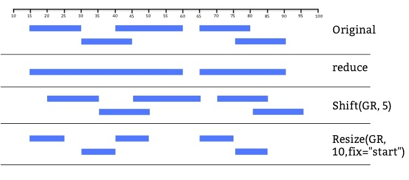

## Operations on GenomicRanges

```r
head(ranges(gr1))
```

```
## IRanges of length 6
##     start end width names
## [1]    11  50    40     a
## [2]    12  51    40     b
## [3]    13  52    40     c
## [4]    14  53    40     d
## [5]    15  54    40     e
## [6]    16  55    40     f
```

```r
start(gr1)
```

```
##  [1] 11 12 13 14 15 16 17 18 19 20
```

```r
width(gr1)
```

```
##  [1] 40 40 40 40 40 40 40 40 40 40
```

## Operations on GenomicRanges

Subsetting GRanges

```r
gr1[seqnames(gr1)=="chr1"]
```

```
## GRanges object with 3 ranges and 2 metadata columns:
##     seqnames    ranges strand |     score                GC
##        <Rle> <IRanges>  <Rle> | <integer>         <numeric>
##   a     chr1  [11, 50]      - |         1 0.477659597061574
##   e     chr1  [15, 54]      - |         5 0.129954402102157
##   f     chr1  [16, 55]      + |         6 0.679821707308292
##   -------
##   seqinfo: 3 sequences from an unspecified genome; no seqlengths
```

Merge overlapping genomic ranges within the same GRanges object

```r
reduce(gr1)
```

```
## GRanges object with 6 ranges and 0 metadata columns:
##       seqnames    ranges strand
##          <Rle> <IRanges>  <Rle>
##   [1]     chr1  [16, 55]      +
##   [2]     chr1  [11, 54]      -
##   [3]     chr2  [12, 52]      +
##   [4]     chr2  [14, 53]      -
##   [5]     chr3  [17, 57]      +
##   [6]     chr3  [19, 59]      -
##   -------
##   seqinfo: 3 sequences from an unspecified genome; no seqlengths
```

## Finding overlapping regions

- One of the common tasks in Sequencing data analysis
- Ex: Identifying transcription factor binding sites overlap with promoters
- **findOverlaps** function finds intervals overlap between two GRanges object.
- Usage: **function(query,subject)**

```r
gr1_overlaps <- findOverlaps(gr1,gr2,ignore.strand=F)
gr1_overlaps
```

```
## Hits of length 5
## queryLength: 10
## subjectLength: 10
##   queryHits subjectHits
##    <integer>   <integer>
##  1         6           1
##  2         9           2
##  3         9           3
##  4        10           2
##  5        10           3
```

Output of findOverlaps is a 'Hits' object indicating which of the query and subject intervals overlap.

## Finding overlapping regions

Convert the 'Hits' object to 2 column matrix using **as.matrix()**. Values in the first column are indices of the query and values in second column are indices of the subject.

```r
gr1_overlaps.m <- as.matrix(gr1_overlaps)
gr1[gr1_overlaps.m[,"queryHits"], ]
```

```
## GRanges object with 5 ranges and 2 metadata columns:
##     seqnames    ranges strand |     score                GC
##        <Rle> <IRanges>  <Rle> | <integer>         <numeric>
##   f     chr1  [16, 55]      + |         6 0.679821707308292
##   i     chr3  [19, 58]      - |         9 0.120910730911419
##   i     chr3  [19, 58]      - |         9 0.120910730911419
##   j     chr3  [20, 59]      - |        10 0.853072010213509
##   j     chr3  [20, 59]      - |        10 0.853072010213509
##   -------
##   seqinfo: 3 sequences from an unspecified genome; no seqlengths
```

## Finding overlapping regions - %in% and %over%

Alternate ways of find overlapping regions

```r
gr1[gr1 %in% gr2]
```

```
## GRanges object with 0 ranges and 2 metadata columns:
##    seqnames    ranges strand |     score        GC
##       <Rle> <IRanges>  <Rle> | <integer> <numeric>
##   -------
##   seqinfo: 3 sequences from an unspecified genome; no seqlengths
```

```r
gr1[gr1 %over% gr2]
```

```
## GRanges object with 3 ranges and 2 metadata columns:
##     seqnames    ranges strand |     score                GC
##        <Rle> <IRanges>  <Rle> | <integer>         <numeric>
##   f     chr1  [16, 55]      + |         6 0.679821707308292
##   i     chr3  [19, 58]      - |         9 0.120910730911419
##   j     chr3  [20, 59]      - |        10 0.853072010213509
##   -------
##   seqinfo: 3 sequences from an unspecified genome; no seqlengths
```

Note the difference between %in% and %over%

## Finding overlapping regions

Other interesting functions: **nearest()** and **distanceToNearest()**

```r
distanceToNearest(gr1,gr2,ignore.strand=F)
```

```
## Hits of length 10
## queryLength: 10
## subjectLength: 10
##    queryHits subjectHits  distance
##     <integer>   <integer> <integer>
##  1          1           5         8
##  2          2          NA        NA
##  3          3          NA        NA
##  4          4           4         4
##  5          5           5         4
##  6          6           1         0
##  7          7           7         4
##  8          8           7         3
##  9          9           3         0
##  10        10           3         0
```

## precede, follow

Find nearest range in gr2 that precede or follow each range in gr1

```r
precede(gr1,gr2)
```

```
##  [1] NA NA NA NA NA  6  7  7 NA NA
```

```r
follow(gr1,gr2)
```

```
##  [1]  5 NA NA  4  5 NA NA NA  9  9
```

precede, follow returns the index of previous/next ranges. Overlapping ranges are excluded

## Set operations

- Operations between individual ranges within two GRanges object
- punion, pintersect, psetdiff

Example: Finding number of overlapping bases between TFBS and promoters (using pintersect).

## Computing Coverage

**coverage** calculates how many ranges overlap with individual positions in the genome. **coverage** function returns the coverage as Rle instance.

```r
coverage(gr1)
```

```
## RleList of length 3
## $chr1
## integer-Rle of length 55 with 6 runs
##   Lengths: 10  4  1 35  4  1
##   Values :  0  1  2  3  2  1
##
## $chr2
## integer-Rle of length 53 with 6 runs
##   Lengths: 11  1  1 38  1  1
##   Values :  0  1  2  3  2  1
##
## $chr3
## integer-Rle of length 59 with 8 runs
##   Lengths: 16  1  1  1 37  1  1  1
##   Values :  0  1  2  3  4  3  2  1
```

## Annotating Peaks

- Associate peaks to promoters / TSS / Enhancers etc
- Bioconductor Packages: ChIPPeakAnno, ChIPseeker
- Functional annotation: GREAT (http://bejerano.stanford.edu/), GSEA

## ChIPseeker

Peak Coverage plot across chromosome

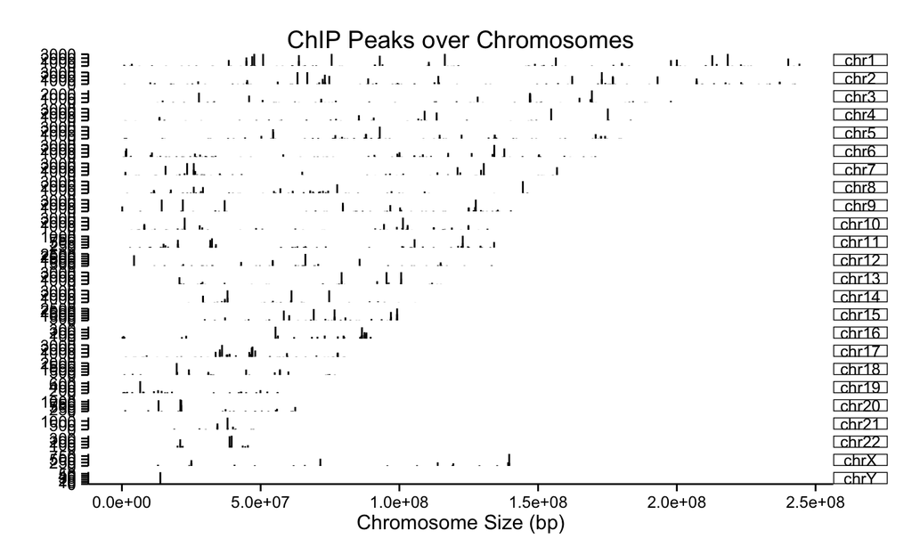

```r
library(ChIPseeker)
library(TxDb.Hsapiens.UCSC.hg19.knownGene)
txdb <- TxDb.Hsapiens.UCSC.hg19.knownGene

## Sample files
files <- getSampleFiles()
peak <- readPeakFile(files[[4]])
covplot(peak, weightCol="V5")
```

## Peak Annotation & Visualisation

```r
# Reading the peak file
peakAnno <- annotatePeak(files[[4]], tssRegion=c(-3000, 3000),TxDb=txdb, annoDb="org.Hs.eg.db")
```

```
## >> loading peak file...               2015-12-12 15:29:00
## >> preparing features information...      2015-12-12 15:29:00
## >> identifying nearest features...        2015-12-12 15:29:02
## >> calculating distance from peak to TSS...   2015-12-12 15:29:03
## >> assigning genomic annotation...        2015-12-12 15:29:03
## >> adding gene annotation...          2015-12-12 15:29:39
## >> assigning chromosome lengths           2015-12-12 15:29:39
## >> done...                    2015-12-12 15:29:39
```

## Pie chart

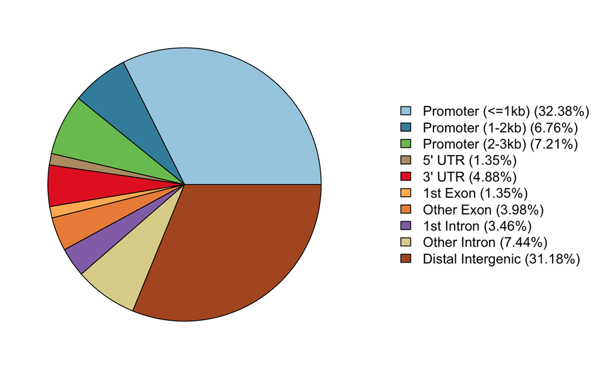

```r
plotAnnoPie(peakAnno)
```

## Bar chart

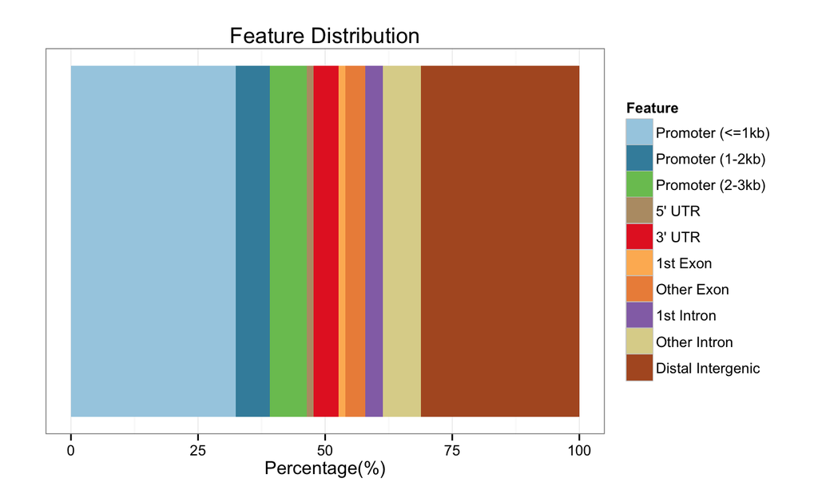

```r
plotAnnoBar(peakAnno)
```

## Plot distance between Peaks and TSS

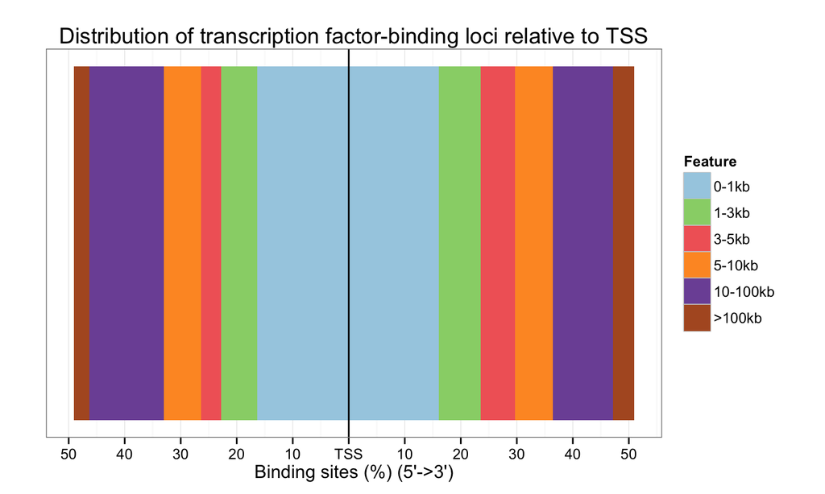

```r
plotDistToTSS(peakAnno)
```